# A Study on the Prevalence of Obesity, Cholesterol, Diabetes and Other Factors

Tan Guan San, Koo Tse Kain

17 Mar 2019

# Data Science Project on Diabetes

## Problem Statements

Diabetes is a chronic disease where the human body produces insufficient insulin to help the cells of the body use the glucose in food, resulting in high blood glucose level.

The disease has quadrupled over the last 35 years (WHO) In Singapore we have observed higher prevalence compared to other parts of the world.

1. 9% in 1998 from 8.6% in 1992
2. Cost > S$1.9bn in 2010 and
3. Projected beyond S$2.5bn by 2050

Two types of diabetes:

1. Type 1 - Genetic and unpreventable
2. Type 2 - Related to weight - Body Mass Index(BMI), Waist-Hip Ratio(WHR), Frame.

Best Screening Test & Requirement:

1. Fasting plasma glucose (HBA1C test or A1C) of which readings 6.5 and above are diagnosed as diabetics.
2. Fasting time at least two hours and more (Postprandial Time) before the A1C test.

In our Capstone Project, we set to explore:

1. Prevalence of diabetes is dependent on high body mass index, i.e. overweight and/or obese individuals have a higher risk of high glucose level.
2. Females are more likely than males to have diabetes.
3. Middle Age and Elderly persons (above 65 years old) have higher risk than Adults (below 40) to have Type 2 diabetes. Frame size and high glucose level are correlated positively.
4. Co-morbidity of high cholesterols and high glucose level increase the risk of diabetes ie they have positive correlationship.
5. Waist-to-hip ratio (WHR), an alternate classification of weight categories, is a more robust predictor on prevalence of diabetes.

For our data science project, we activated the following libraries, using the `Tidyverse` approach.

```r
library("ggcorrplot")
library("tidyverse")
library("Hmisc")
library("readxl")
library("modelr")
library("broom")              # Modelling in R
library ("gplots")
library("gridExtra")          # For side by side visualisation display
library("MBESS")              # or Report in Word Format
library("gvlma")
library("knitr")
library("QuantPsyc")
```

## Import

Then, we imported our dataset from our local drive.

```r
diabetes <- read_csv("diabetes.csv")
```

Within the dataset, there is a Glycosylated Haemoglobin (glyhb) variable, which will serve as our dependent (*continuous y*) variable.

Also, the dataset contains various other independent variables like total cholesterol, height, weight, gender, frame, waist size, hip size which serves as our X variables (continous and discrete).

Out of the 8 variables, obesity is defined using Body Mass Index (BMI) measurements which is computed using the Weight and Height variables. Similiarly, Waist-Hip Ratio (WHR) is computed using Waist and Hip Sizes variables. These 2 new derived variables also serves as our independent variables (“X”).

We have 3 moderators as follows:

```r
glimpse(diabetes)
```

```
## Observations: 403
## Variables: 19
## $ id       <int> 1000, 1001, 1002, 1003, 1005, 1008, 1011, 1015, 1016,...
## $ chol     <int> 203, 165, 228, 78, 249, 248, 195, 227, 177, 263, 242,...
## $ stab.glu <int> 82, 97, 92, 93, 90, 94, 92, 75, 87, 89, 82, 128, 75, ...
## $ hdl      <int> 56, 24, 37, 12, 28, 69, 41, 44, 49, 40, 54, 34, 36, 4...
## $ ratio    <dbl> 3.6, 6.9, 6.2, 6.5, 8.9, 3.6, 4.8, 5.2, 3.6, 6.6, 4.5...
## $ glyhb    <dbl> 4.31, 4.44, 4.64, 4.63, 7.72, 4.81, 4.84, 3.94, 4.84,...
## $ location <chr> "Buckingham", "Buckingham", "Buckingham", "Buckingham...
## $ age      <int> 46, 29, 58, 67, 64, 34, 30, 37, 45, 55, 60, 38, 27, 4...
## $ gender   <chr> "female", "female", "female", "male", "male", "male",...
## $ height   <int> 62, 64, 61, 67, 68, 71, 69, 59, 69, 63, 65, 58, 60, 5...
## $ weight   <int> 121, 218, 256, 119, 183, 190, 191, 170, 166, 202, 156...
## $ frame    <chr> "medium", "large", "large", "large", "medium", "large...
## $ bp.1s    <int> 118, 112, 190, 110, 138, 132, 161, NA, 160, 108, 130,...
## $ bp.1d    <int> 59, 68, 92, 50, 80, 86, 112, NA, 80, 72, 90, 68, 80, ...
## $ bp.2s    <int> NA, NA, 185, NA, NA, NA, 161, NA, 128, NA, 130, NA, N...
## $ bp.2d    <int> NA, NA, 92, NA, NA, NA, 112, NA, 86, NA, 90, NA, NA, ...
## $ waist    <int> 29, 46, 49, 33, 44, 36, 46, 34, 34, 45, 39, 42, 35, 3...
## $ hip      <int> 38, 48, 57, 38, 41, 42, 49, 39, 40, 50, 45, 50, 41, 4...
## $ time.ppn <int> 720, 360, 180, 480, 300, 195, 720, 1020, 300, 240, 30...
```

## Tidy & Transform

The first thing we did with our loaded dataset was to identify any invalid or incomplete observations and select valid cases (no missing observations).

Also, we performed the following:

1. Rename these variables: time.ppn, stab.glu and bp. Replace “.” with “_“.
2. Compute the BMI and WHR variables
3. Categorise Age, BMI, WHR and Cholestorol into following groups: age into age_grp; bmi into bmi_grp, whr into whr_grp and chol into chol_grp
4. With Postprandial Time (time_ppn) as the criteria, these dataframes are made: diabetes120 : contains records for time_ppn > 120 minutes diabetes480 : contains records for time_ppn between 120 to 480 minutes

```r
###############################################################################
#   Dataset 1: No fasting time criteria
###############################################################################

# Identify the presence of invalid or incomplete observations

summary (diabetes[c("chol","hdl", "ratio","glyhb","age","gender",
                     "height","weight","frame",
                     "waist", "hip","time.ppn")])
```

```
##       chol            hdl             ratio            glyhb
##  Min.   : 78.0   Min.   : 12.00   Min.   : 1.500   Min.   : 2.68
##  1st Qu.:179.0   1st Qu.: 38.00   1st Qu.: 3.200   1st Qu.: 4.38
##  Median :204.0   Median : 46.00   Median : 4.200   Median : 4.84
##  Mean   :207.8   Mean   : 50.45   Mean   : 4.522   Mean   : 5.59
##  3rd Qu.:230.0   3rd Qu.: 59.00   3rd Qu.: 5.400   3rd Qu.: 5.60
##  Max.   :443.0   Max.   :120.00   Max.   :19.300   Max.   :16.11
##  NA's   :1       NA's   :1        NA's   :1        NA's   :13
##       age           gender              height          weight
##  Min.   :19.00   Length:403         Min.   :52.00   Min.   : 99.0
##  1st Qu.:34.00   Class :character   1st Qu.:63.00   1st Qu.:151.0
##  Median :45.00   Mode  :character   Median :66.00   Median :172.5
##  Mean   :46.85                      Mean   :66.02   Mean   :177.6
##  3rd Qu.:60.00                      3rd Qu.:69.00   3rd Qu.:200.0
##  Max.   :92.00                      Max.   :76.00   Max.   :325.0
##                                     NA's   :5       NA's   :1
##     frame               waist           hip           time.ppn
##  Length:403         Min.   :26.0   Min.   :30.00   Min.   :   5.0
##  Class :character   1st Qu.:33.0   1st Qu.:39.00   1st Qu.:  90.0
##  Mode  :character   Median :37.0   Median :42.00   Median : 240.0
##                     Mean   :37.9   Mean   :43.04   Mean   : 341.2
##                     3rd Qu.:41.0   3rd Qu.:46.00   3rd Qu.: 517.5
##                     Max.   :56.0   Max.   :64.00   Max.   :1560.0
##                     NA's   :2      NA's   :2       NA's   :3
```

```r
#   Select cases with complete observations (no missing data)

diabetes <- diabetes[complete.cases(diabetes[,c("chol","hdl", "ratio","glyhb",
                                                  "height","weight","frame",
                                                  "waist", "hip","time.ppn")]),]


summary (diabetes[c("chol","hdl", "ratio","glyhb","age","gender",
                    "height","weight","frame",
                    "waist", "hip","time.ppn")])
```

```
##       chol            hdl             ratio           glyhb
##  Min.   : 78.0   Min.   : 12.00   Min.   : 1.50   Min.   : 2.680
##  1st Qu.:179.0   1st Qu.: 38.00   1st Qu.: 3.20   1st Qu.: 4.390
##  Median :203.0   Median : 46.00   Median : 4.20   Median : 4.860
##  Mean   :207.4   Mean   : 50.19   Mean   : 4.54   Mean   : 5.594
##  3rd Qu.:228.0   3rd Qu.: 59.00   3rd Qu.: 5.40   3rd Qu.: 5.630
##  Max.   :443.0   Max.   :120.00   Max.   :19.30   Max.   :16.110
##       age           gender              height          weight
##  Min.   :19.00   Length:369         Min.   :52.00   Min.   : 99.0
##  1st Qu.:34.00   Class :character   1st Qu.:63.00   1st Qu.:151.0
##  Median :45.00   Mode  :character   Median :66.00   Median :174.0
##  Mean   :46.64                      Mean   :66.03   Mean   :178.1
##  3rd Qu.:60.00                      3rd Qu.:69.00   3rd Qu.:200.0
##  Max.   :92.00                      Max.   :76.00   Max.   :325.0
##     frame               waist            hip           time.ppn
##  Length:369         Min.   :26.00   Min.   :30.00   Min.   :   5.0
##  Class :character   1st Qu.:33.00   1st Qu.:39.00   1st Qu.:  90.0
##  Mode  :character   Median :37.00   Median :42.00   Median : 240.0
##                     Mean   :37.94   Mean   :43.06   Mean   : 339.9
##                     3rd Qu.:42.00   3rd Qu.:46.00   3rd Qu.: 480.0
##                     Max.   :56.00   Max.   :64.00   Max.   :1560.0
```

```r
#   Rename variables

names(diabetes)[names(diabetes) == "time.ppn"] <- "time_ppn"
names(diabetes)[names(diabetes)=="stab.glu"] <- "stab_glu"
names(diabetes) <- gsub("bp.", "bp_", names(diabetes))
glimpse(diabetes)
```

```
## Observations: 369
## Variables: 19
## $ id       <int> 1000, 1001, 1002, 1003, 1005, 1008, 1011, 1015, 1016,...
## $ chol     <int> 203, 165, 228, 78, 249, 248, 195, 227, 177, 263, 242,...
## $ stab_glu <int> 82, 97, 92, 93, 90, 94, 92, 75, 87, 89, 82, 128, 75, ...
## $ hdl      <int> 56, 24, 37, 12, 28, 69, 41, 44, 49, 40, 54, 34, 36, 4...
## $ ratio    <dbl> 3.6, 6.9, 6.2, 6.5, 8.9, 3.6, 4.8, 5.2, 3.6, 6.6, 4.5...
## $ glyhb    <dbl> 4.31, 4.44, 4.64, 4.63, 7.72, 4.81, 4.84, 3.94, 4.84,...
## $ location <chr> "Buckingham", "Buckingham", "Buckingham", "Buckingham...
## $ age      <int> 46, 29, 58, 67, 64, 34, 30, 37, 45, 55, 60, 38, 27, 4...
## $ gender   <chr> "female", "female", "female", "male", "male", "male",...
## $ height   <int> 62, 64, 61, 67, 68, 71, 69, 59, 69, 63, 65, 58, 60, 5...
## $ weight   <int> 121, 218, 256, 119, 183, 190, 191, 170, 166, 202, 156...
## $ frame    <chr> "medium", "large", "large", "large", "medium", "large...
## $ bp_1s    <int> 118, 112, 190, 110, 138, 132, 161, NA, 160, 108, 130,...
## $ bp_1d    <int> 59, 68, 92, 50, 80, 86, 112, NA, 80, 72, 90, 68, 80, ...
## $ bp_2s    <int> NA, NA, 185, NA, NA, NA, 161, NA, 128, NA, 130, NA, N...
## $ bp_2d    <int> NA, NA, 92, NA, NA, NA, 112, NA, 86, NA, 90, NA, NA, ...
## $ waist    <int> 29, 46, 49, 33, 44, 36, 46, 34, 34, 45, 39, 42, 35, 3...
## $ hip      <int> 38, 48, 57, 38, 41, 42, 49, 39, 40, 50, 45, 50, 41, 4...
## $ time_ppn <int> 720, 360, 180, 480, 300, 195, 720, 1020, 300, 240, 30...
```

```r
#   Compute and create the BMI and WHR variables

diabetes$bmi<-round(((diabetes$weight*703)/(diabetes$height)^2),0)
diabetes$whr<-round((diabetes$waist/diabetes$hip),2)
summary(diabetes)
```

```
##        id             chol          stab_glu          hdl
##  Min.   : 1000   Min.   : 78.0   Min.   : 48.0   Min.   : 12.00
##  1st Qu.: 4792   1st Qu.:179.0   1st Qu.: 81.0   1st Qu.: 38.00
##  Median :15766   Median :203.0   Median : 90.0   Median : 46.00
##  Mean   :16045   Mean   :207.4   Mean   :107.2   Mean   : 50.19
##  3rd Qu.:20332   3rd Qu.:228.0   3rd Qu.:108.0   3rd Qu.: 59.00
##  Max.   :41752   Max.   :443.0   Max.   :385.0   Max.   :120.00
##
##      ratio           glyhb          location              age
##  Min.   : 1.50   Min.   : 2.680   Length:369         Min.   :19.00
##  1st Qu.: 3.20   1st Qu.: 4.390   Class :character   1st Qu.:34.00
##  Median : 4.20   Median : 4.860   Mode  :character   Median :45.00
##  Mean   : 4.54   Mean   : 5.594                      Mean   :46.64
##  3rd Qu.: 5.40   3rd Qu.: 5.630                      3rd Qu.:60.00
##  Max.   :19.30   Max.   :16.110                      Max.   :92.00
##
##     gender              height          weight         frame
##  Length:369         Min.   :52.00   Min.   : 99.0   Length:369
##  Class :character   1st Qu.:63.00   1st Qu.:151.0   Class :character
##  Mode  :character   Median :66.00   Median :174.0   Mode  :character
##                     Mean   :66.03   Mean   :178.1
##                     3rd Qu.:69.00   3rd Qu.:200.0
##                     Max.   :76.00   Max.   :325.0
##
##      bp_1s           bp_1d            bp_2s           bp_2d
##  Min.   : 90.0   Min.   : 48.00   Min.   :110.0   Min.   : 60.00
##  1st Qu.:121.2   1st Qu.: 75.00   1st Qu.:138.2   1st Qu.: 84.00
##  Median :136.0   Median : 82.00   Median :150.0   Median : 92.00
##  Mean   :137.2   Mean   : 83.36   Mean   :153.1   Mean   : 92.52
##  3rd Qu.:148.0   3rd Qu.: 92.00   3rd Qu.:160.8   3rd Qu.:100.00
##  Max.   :250.0   Max.   :124.00   Max.   :238.0   Max.   :124.00
##  NA's   :3       NA's   :3        NA's   :239     NA's   :239
##      waist            hip           time_ppn           bmi
##  Min.   :26.00   Min.   :30.00   Min.   :   5.0   Min.   :16.00
##  1st Qu.:33.00   1st Qu.:39.00   1st Qu.:  90.0   1st Qu.:24.00
##  Median :37.00   Median :42.00   Median : 240.0   Median :28.00
##  Mean   :37.94   Mean   :43.06   Mean   : 339.9   Mean   :28.82
##  3rd Qu.:42.00   3rd Qu.:46.00   3rd Qu.: 480.0   3rd Qu.:32.00
##  Max.   :56.00   Max.   :64.00   Max.   :1560.0   Max.   :56.00
##
##       whr
##  Min.   :0.6800
##  1st Qu.:0.8300
##  Median :0.8800
##  Mean   :0.8813
##  3rd Qu.:0.9300
##  Max.   :1.1400
##
```

```r
#   Categorise age into three groups
#   19 - 39: Adult (1); 40 - 65: Middle Age (2);  >65: Elderly (3)

table(diabetes$age, useNA = "always")
```

```
##
##   19   20   21   22   23   24   25   26   27   28   29   30   31   32   33
##    2   10    6    5    6    1    3    6    9    8    7    8    9    3    6
##   34   35   36   37   38   39   40   41   42   43   44   45   46   47   48
##    6    5   11   11   10    2   15   11    7   11    5    8    4    7    6
##   49   50   51   52   53   54   55   56   57   58   59   60   61   62   63
##    4   10    6    8    6    5    7    4    3    5    8   10    7    5   11
##   64   65   66   67   68   69   70   71   72   73   74   75   76   78   79
##    5    6    7    4    4    1    4    4    3    2    3    2    4    4    1
##   80   81   82   83   84   89   92 <NA>
##    2    1    1    1    1    1    1    0
```

```r
diabetes$age_grp <- NA                        # Initialise new variable
diabetes$age_grp[diabetes$age > 18 & diabetes$age < 40] <- "Adult"
diabetes$age_grp[diabetes$age > 39 & diabetes$age < 66] <- "Middle Age"
diabetes$age_grp[diabetes$age > 65 & diabetes$age < 93] <- "Elderly"
table(diabetes$age_grp, useNA = "always")
```

```
##
##      Adult    Elderly Middle Age       <NA>
##        134         51        184          0
```

```r
#   Group bmi into four groups based on WHO classification
#   UW: Underweight;  NW: Normal Weight;  OW: Overweight;   OB: Obese

table(diabetes$bmi, useNA = "always")
```

```
##
##   16   17   18   19   20   21   22   23   24   25   26   27   28   29   30
##    1    2    5   11   12    9   23   21   13   29   20   27   28   14   30
##   31   32   33   34   35   36   37   38   39   40   41   42   43   44   45
##   20   14   12   13   12    6    7    6    4    4    8    2    6    2    3
##   48   49   50   51   56 <NA>
##    1    1    1    1    1    0
```

```r
diabetes$bmi_grp <- NA                     # Initialise new variable
diabetes$bmi_grp[diabetes$bmi<18.5] <- "UW"
diabetes$bmi_grp[diabetes$bmi>18.5 & diabetes$bmi<25.0] <- "NW"
diabetes$bmi_grp[diabetes$bmi>24.9 & diabetes$bmi<30.0] <- "OW"
diabetes$bmi_grp[diabetes$bmi>29.9] <- "OB"
table(diabetes$bmi_grp, useNA = "always")
```

```
##
##   NW   OB   OW   UW <NA>
##   89  154  118    8    0
```

```r
#   Group whr into 2 groups and compute based on gender
#   High: High;  Mod: Moderate or Below

table(diabetes$whr, useNA = "always")
```

```
##
## 0.68  0.7 0.72 0.73 0.74 0.75 0.76 0.77 0.78 0.79  0.8 0.81 0.82 0.83 0.84
##    1    1    3    1    4    2    6    3    9   14   14    7   18   18   19
## 0.85 0.86 0.87 0.88 0.89  0.9 0.91 0.92 0.93 0.94 0.95 0.96 0.97 0.98    1
##   17   18   19   21   18   27   17   18   11   19   16    4    6   16    5
## 1.02 1.03 1.04 1.05 1.06 1.07 1.08 1.09 1.14 <NA>
##    2    2    2    3    1    2    1    2    2    0
```

```r
diabetes$whr_grp <- NA                    # Initialise new variable
diabetes$whr_grp[diabetes$whr<=0.86 & diabetes$gender == "female"] <- "Mod"
diabetes$whr_grp[diabetes$whr>0.86 & diabetes$gender == "female"] <- "High"
diabetes$whr_grp[diabetes$whr<=1.00 & diabetes$gender == "male"] <- "Mod"
diabetes$whr_grp[diabetes$whr>1.00 & diabetes$gender == "male"] <- "High"
table(diabetes$whr_grp, useNA = "always")
```

```
##
## High  Mod <NA>
##  108  261    0
```

```r
#   Group Total cholestorol (chol) into 3 groups
#   D : Desirable;  BH: Borderline High Risk, H = High Risk

table(diabetes$chol, useNA = "always")
```

```
##
##   78  118  128  129  132  134  135  136  138  140  142  143  144  145  146
##    1    1    1    1    2    1    2    1    2    1    1    2    1    1    2
##  147  148  149  150  151  152  155  156  157  158  159  160  162  163  164
##    1    1    2    1    2    1    2    1    3    2    3    5    2    2    4
##  165  166  168  169  170  171  172  173  174  175  176  177  178  179  180
##    3    1    3    3    4    3    3    4    5    1    2    2    2   11    3
##  181  182  183  184  185  186  187  188  189  190  191  192  193  194  195
##    5    4    3    4    3    2    1    4    4    4    5    4    5    7    3
##  196  197  198  199  200  201  202  203  204  205  206  207  208  209  210
##    3    1    3    6    1    3    2    6    9    1    5    5    2    5    1
##  211  212  213  214  215  216  217  218  219  220  221  222  223  224  225
##    3    4    3    3    7    3    4    3    7    2    2    1    3    4    3
##  226  227  228  229  230  231  232  233  234  235  236  237  238  239  240
##    3    4    5    2    2    2    1    1    1    4    2    3    1    2    2
##  241  242  243  244  245  246  248  249  251  252  254  255  260  261  262
##    2    4    2    2    2    1    1    3    2    1    3    3    2    1    1
##  263  265  266  267  268  269  270  271  273  277  279  281  283  284  289
##    2    1    1    1    2    2    1    2    1    2    1    1    2    1    2
##  293  296  300  301  302  305  306  307  318  337  342  347  404  443 <NA>
##    3    2    1    1    1    1    1    1    1    1    1    1    1    1    0
```

```r
diabetes$chol_grp <- NA                    # Initialise new variable
diabetes$chol_grp[diabetes$chol<200] <- "D"
diabetes$chol_grp[diabetes$chol>=200 & diabetes$chol<239] <- "BH"
diabetes$chol_grp[diabetes$chol>= 240] <- "H"
table(diabetes$chol_grp, useNA = "always")
```

```
##
##   BH    D    H <NA>
##  123  173   71    2
```

```r
##   Streamliine the data set - tightening the fasting time criteria
###############################################################################
#    Dataset 2:
#    Fasting time criteria: time_ppn = or > 120 minutes

table(diabetes$time_ppn, useNA = "always")
```

```
##
##    5   10   15   20   30   40   45   60   75   80   90  105  120  135  140
##    1    9    8    5   17    1    3   32    1    1   15    1   17    2    1
##  150  180  195  210  225  240  255  260  270  285  300  315  330  360  375
##   12   25    6   15    4   28    1    1   11    2   18    1    6    6    1
##  390  420  435  450  480  540  570  600  630  660  690  720  750  780  795
##    5    9    1    4    9    6    1    2    1    2    2   34    1   11    1
##  840  855  900  960  990 1020 1080 1140 1170 1200 1260 1320 1440 1560 <NA>
##    3    1    7    3    1    4    1    1    1    1    1    1    3    1    0
```

```r
#   Build data frame

diabetes120 <- diabetes %>%
    filter(time_ppn >= 120)
table(diabetes120$time_ppn)
```

```
##
##  120  135  140  150  180  195  210  225  240  255  260  270  285  300  315
##   17    2    1   12   25    6   15    4   28    1    1   11    2   18    1
##  330  360  375  390  420  435  450  480  540  570  600  630  660  690  720
##    6    6    1    5    9    1    4    9    6    1    2    1    2    2   34
##  750  780  795  840  855  900  960  990 1020 1080 1140 1170 1200 1260 1320
##    1   11    1    3    1    7    3    1    4    1    1    1    1    1    1
## 1440 1560
##    3    1
```

```r
###############################################################################
#   Dataset 3
#   Fasting time criteria:  time_ppn equal and more than 120 minutes and
#   those less than 8 hours (480 minutes)

diabetes480 <- diabetes120 %>%
    filter(time_ppn > 119.9 & time_ppn < 480.1)
table(diabetes480$time_ppn)
```

```
##
## 120 135 140 150 180 195 210 225 240 255 260 270 285 300 315 330 360 375
##  17   2   1  12  25   6  15   4  28   1   1  11   2  18   1   6   6   1
## 390 420 435 450 480
##   5   9   1   4   9
```

## Model 1: BMI Against A1C Test Results - Scatter Plot

We used ggplot to generate scatter plot that includes geom_smooth for statistical modelling using loess for visual comparison of the 3 datasets so that we could make a more informed decision on the most appropriate dataset for subsequent analysis.

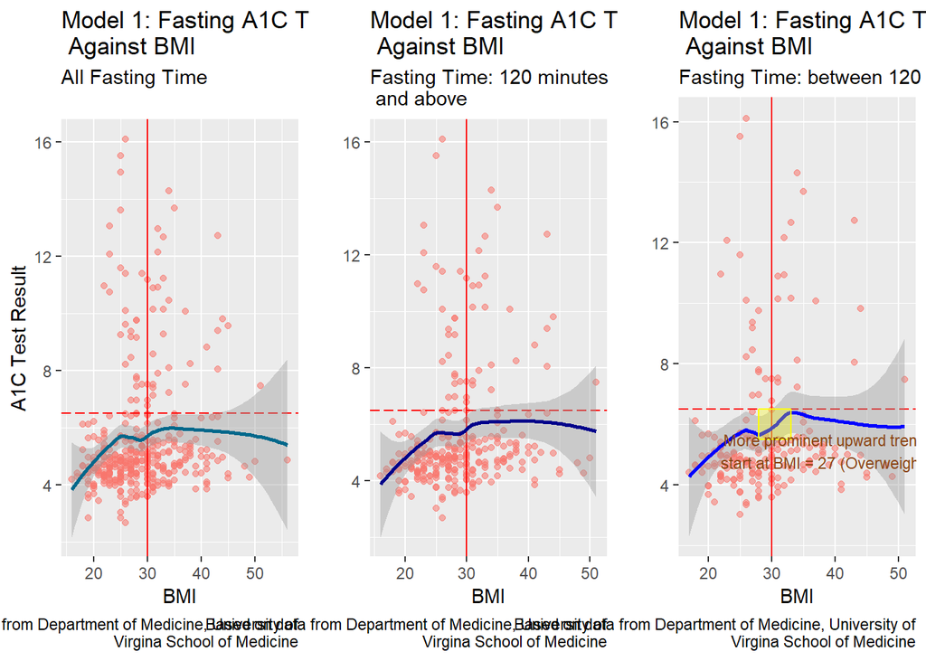

```r
##  Modelling with Visualization Section
#   Both Y (glyhb) and X (bmi) variables are numeric - scatter plot
#   Visualization with regression modeling
#   Side by side display function required

require(gridExtra)

#   Dataset 1

f1 <-
diabetes %>%
    ggplot(aes(y = glyhb, x = bmi)) +
    geom_point(mapping = aes(color = "deepskyblue4", alpha = 0.5),
               na.rm = TRUE) +
    geom_vline(xintercept = 30, color = "red") +
    geom_hline(yintercept = 6.5, color = "red", linetype="longdash") +
    geom_smooth(colour="deepskyblue4", na.rm = TRUE, se = TRUE, level = 0.95) +
    labs(x = "BMI", y = "A1C Test Result",
         title = "Model 1: Fasting A1C Test Result \n Against BMI",
         subtitle = "All Fasting Time\n",
         caption = "Based on data from Department of Medicine, University of
         Virgina School of Medicine")+
    theme(legend.position = "none")

#   Dataset 2

f120 <-
diabetes120 %>%
  ggplot(aes(y = glyhb, x = bmi)) +
  geom_point(mapping = aes(color = "deepskyblue4", alpha = 0.5), na.rm = TRUE) +
  geom_vline(xintercept = 30, color = "red") +
  geom_hline(yintercept = 6.5, color = "red", linetype="longdash") +
  geom_smooth(colour="darkblue", na.rm = TRUE, se = TRUE, level = 0.95) +
  labs(x = "BMI", y = "",
       title = "Model 1: Fasting A1C Test Result\n Against BMI",
       subtitle = "Fasting Time: 120 minutes\n and above",
       caption = "Based on data from Department of Medicine, University of
       Virgina School of Medicine") +
  theme(legend.position = "none")

#   Dataset 3

f480 <-
    diabetes480 %>%
    ggplot(aes(y = glyhb, x = bmi)) +
    geom_point(mapping = aes(color = "deepskyblue4", alpha = 0.5), na.rm = TRUE) +
    geom_vline(xintercept = 30, color = "red") +
    geom_hline(yintercept = 6.5, color = "red", linetype="longdash") +
    geom_smooth(colour="blue", na.rm = TRUE, se = TRUE, level = 0.95) +
    labs(x = "BMI", y = "",
         title = "Model 1: Fasting A1C Test Result \n Against BMI",
         subtitle = "Fasting Time: between 120 minutes and 480 minutes",
         caption = "Based on data from Department of Medicine, University of
         Virgina School of Medicine") +
    theme(legend.position = "none") +
    annotate("rect", xmin = 28, xmax = 33, ymin = 5.5, ymax = 6.5,
             alpha = .3, col = "yellow", fill = "yellow") +
    annotate("text", x = 38, y = 5.5, size = 3, col = "chocolate4",
    label = "\n More prominent upward trend\n start at BMI = 27 (Overweight)")
 grid.arrange(f1,f120,f480, ncol=3)
```

Visual Analysis:

For dataset 3, the upward trends for A1C Test result is more prominent when BMI is approximately equal to 27, ie in the Overweight categories

Next, We performed mean-centering transformations and boxplots visualisation to decide which dataset for our subsequent analysis.

## Visualise 1: Box Plots and Mean Plots for BMI Groups

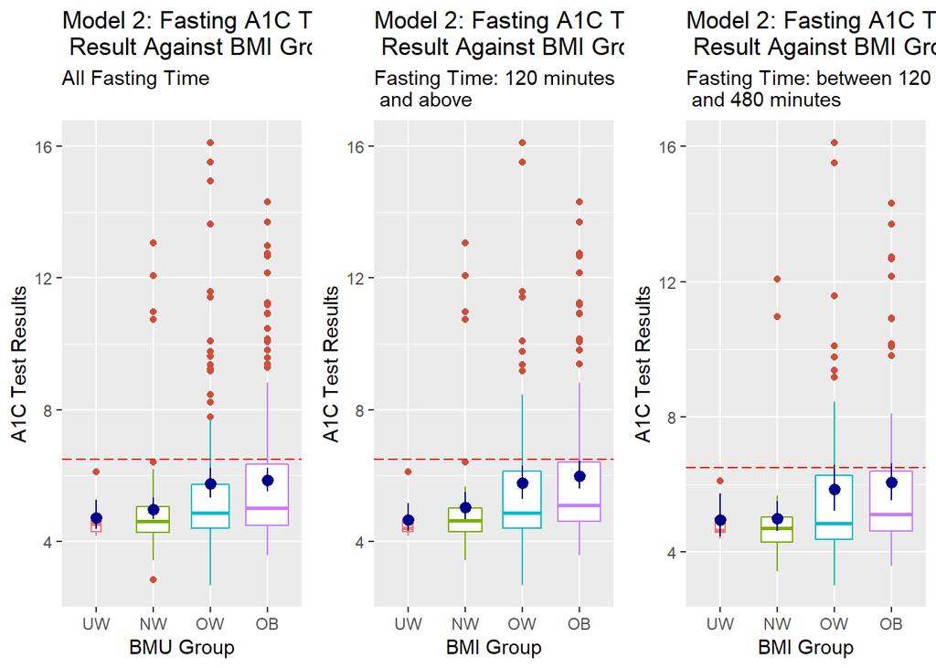

```r
##  Categorised BMI into 4 groups to investigate whether any different
##  between dataset 1, dataset 2 and dataset 3.
##  Data set 1
#   Reroder bmi_grp according to bmi

diabetes$bmi_grp <- reorder(diabetes$bmi_grp, diabetes$bmi)

#   Box plot with means for each categories

b1 <- diabetes %>% ggplot(aes(x = bmi_grp, y = glyhb)) +
  geom_boxplot(aes(color = bmi_grp), na.rm = TRUE, varwidth = TRUE,
               outlier.colour = "tomato3", outlier.size = 1.5) +
  stat_summary(fun.data = mean_cl_boot, geom = "pointrange", col = "darkblue") +
  geom_hline(yintercept = 6.5, color = "red", linetype="longdash") +
  labs(x = "BMU Group", y = "A1C Test Results",
     title = "Model 2: Fasting A1C Test\n Result Against BMI Group",
     subtitle = "All Fasting Time\n") +
  theme(legend.position = "none")

##  Data set 2
#   Reorder bmi_grp according to bmi

diabetes120$bmi_grp <- reorder(diabetes120$bmi_grp, diabetes120$bmi)

#   Box plot with means for each categories

b120 <- diabetes120 %>% ggplot(aes(x = bmi_grp, y = glyhb)) +
    geom_boxplot(aes(color = bmi_grp), na.rm = TRUE, varwidth = TRUE,
                 outlier.colour = "tomato3", outlier.size = 1.5) +
    stat_summary(fun.data = mean_cl_boot, geom = "pointrange", col = "darkblue") +
    geom_hline(yintercept = 6.5, color = "red", linetype="longdash") +
    labs(x = "BMI Group", y = "A1C Test Results",
       title = "Model 2: Fasting A1C Test\n Result Against BMI Group",
       subtitle = "Fasting Time: 120 minutes\n and above") +
    theme(legend.position = "none")

##  Data set 3
#   Reorder bmi_grp according to bmi

diabetes480$bmi_grp <- reorder(diabetes480$bmi_grp, diabetes480$bmi)

#   Box plot with means for each categories

b480 <- diabetes480 %>% ggplot(aes(x = bmi_grp, y = glyhb)) +
  geom_boxplot(aes(color = bmi_grp), na.rm = TRUE, varwidth = TRUE,
               outlier.colour = "tomato3", outlier.size = 1.5) +
  stat_summary(fun.data = mean_cl_boot, geom = "pointrange", col = "darkblue") +
  geom_hline(yintercept = 6.5, color = "red", linetype="longdash") +
  labs(x = "BMI Group", y = "A1C Test Results",
       title = "Model 2: Fasting A1C Test\n Result Against BMI Group",
       subtitle = "Fasting Time: between 120 minutes\n and 480 minutes") +
  theme(legend.position = "none")

#   Display boxplots side by side for comparison

grid.arrange(b1, b120, b480, ncol = 3)
```

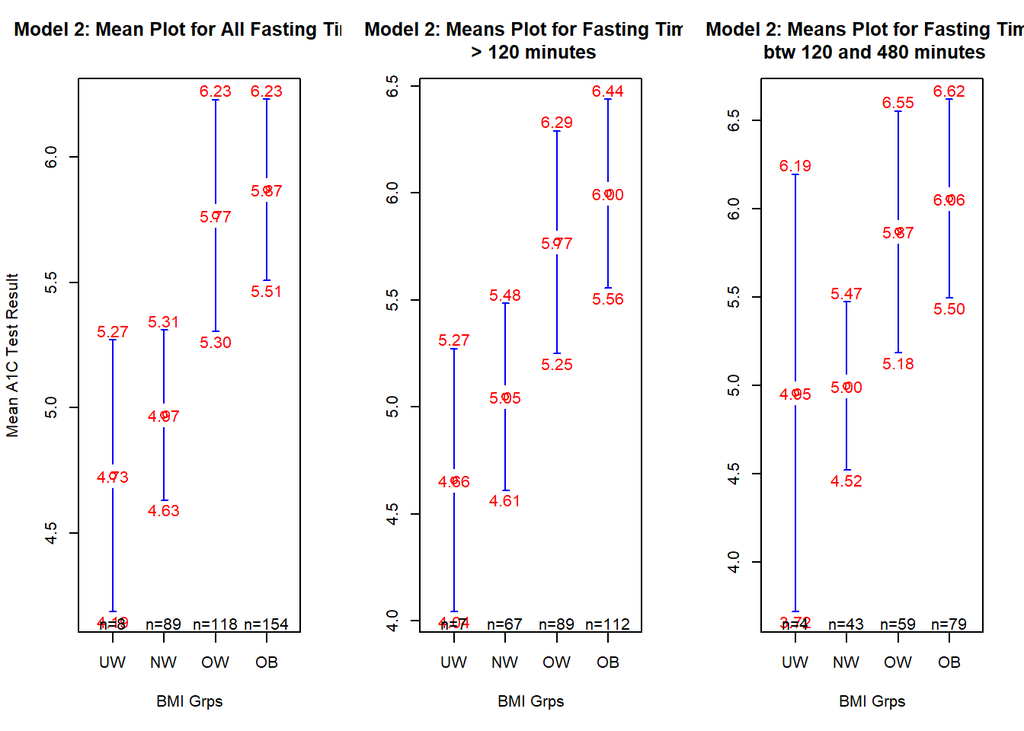

```r
#   Plot Means for all dataset and compare

par(mfrow = c(1,3))

plotmeans(diabetes$glyhb ~ diabetes$bmi_grp, digits = 2, col = "red", ci = TRUE,
           mean.labels = T, ccol = "cyan4", lwd = 2, connect = FALSE,
           xlab = "BMI Grps", ylab = "Mean A1C Test Result",
           main = "Model 2: Mean Plot for All Fasting Time\n")

plotmeans(diabetes120$glyhb ~ diabetes120$bmi_grp, digits = 2, col = "red",
          mean.labels = T, ci = TRUE, ccol = "cyan4", lwd = 2, connect = FALSE,
          xlab = "BMI Grps", ylab = "",
          main = "Model 2: Means Plot for Fasting Time\n > 120 minutes")

plotmeans(diabetes480$glyhb ~ diabetes480$bmi_grp, digits = 2, col = "red",
          mean.labels = T, ci = TRUE, ccol = "cyan4", lwd = 2, connect = FALSE,
          xlab = "BMI Grps", ylab = "",
          main = "Model 2: Means Plot for Fasting Time\n btw 120 and 480 minutes")
```

```r
par(mfrow = c(1,1))
```

Visual Analysis:

The mean plots with the point range indicates that dataset 3 can surfaced potential diabetic results for those who are overweight for two data set could have possibly missed. This indicates the important of strict adherence of the Fasting Time, i.e. Postprandial Time, to between 120 and 480 minutes.

Hence, our decision to use data set 3 (diabetes480) for subsequent analysis from this point onward.

## Visualize 2: BMI Group with Second and Third Predictors: Age Group and Frame

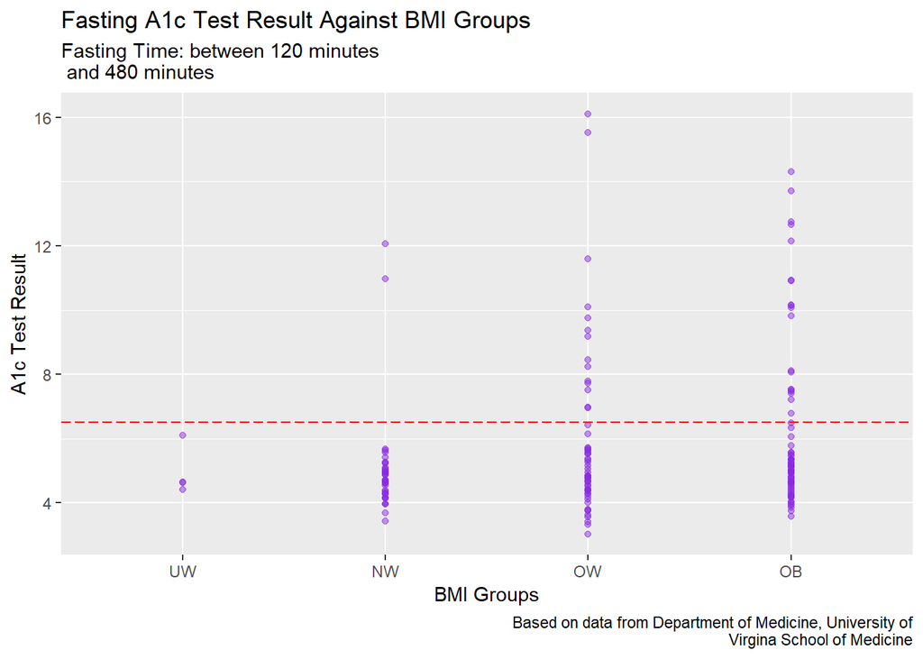

```r
#     Visualisation with categorical bmi_grp as X1

ggplot(data = diabetes480) +
  geom_point(mapping = aes(x = bmi_grp, y = glyhb), na.rm = TRUE,
             color = "blueviolet", alpha = 0.5) +
  geom_hline(yintercept = 6.5, color = "red", linetype="longdash") +
  labs(x = "BMI Groups", y = "A1c Test Result",
       title = "Fasting A1c Test Result Against BMI Groups",
       subtitle = "Fasting Time: between 120 minutes\n and 480 minutes",
       caption = "Based on data from Department of Medicine, University of
         Virgina School of Medicine")
```

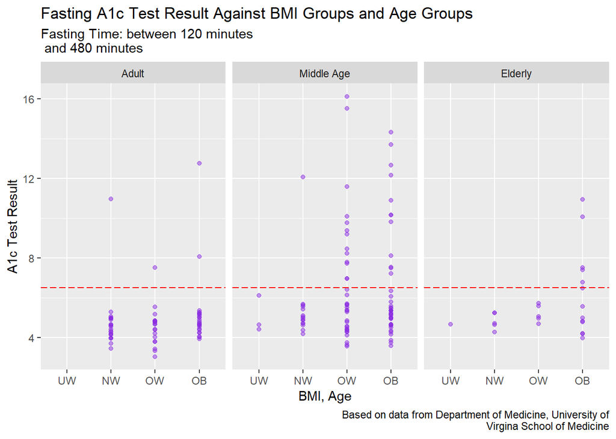

```r
#   Second Predictor - categorical X2: age_grp
diabetes480$age_grp <- reorder(diabetes480$age_grp, diabetes480$age)

ggplot(data=diabetes480) +
  geom_point(mapping = aes(x = bmi_grp, y = glyhb), na.rm = TRUE,
             color = "blueviolet", alpha = 0.5) +
  facet_wrap(age_grp ~ .) +
  geom_hline(yintercept = 6.5, color = "red", linetype="longdash") +
  labs(x = "BMI, Age", y = "A1c Test Result",
       title = "Fasting A1c Test Result Against BMI Groups and Age Groups",
       subtitle = "Fasting Time: between 120 minutes\n and 480 minutes",
       caption = "Based on data from Department of Medicine, University of
       Virgina School of Medicine")
```

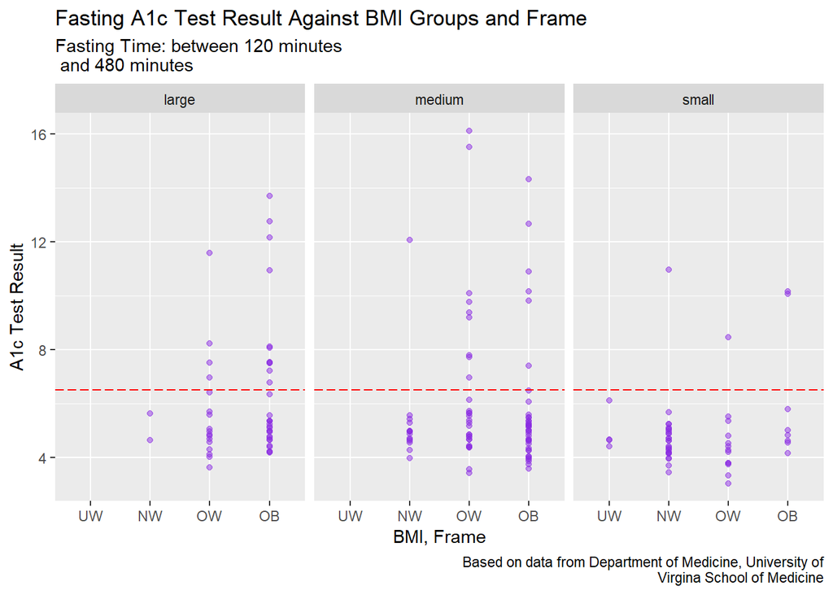

```r
#   Third Predictor - X3: frame

ggplot(data=diabetes480) +
  geom_point(mapping = aes(x = bmi_grp, y = glyhb), na.rm = TRUE,
             color = "blueviolet", alpha = 0.5) +
  facet_wrap( ~ frame) +
  geom_hline(yintercept = 6.5, color = "red", linetype="longdash")+
  labs(x = "BMI, Frame", y = "A1c Test Result",
       title = "Fasting A1c Test Result Against BMI Groups and Frame",
       subtitle = "Fasting Time: between 120 minutes\n and 480 minutes",
       caption = "Based on data from Department of Medicine, University of
       Virgina School of Medicine")
```

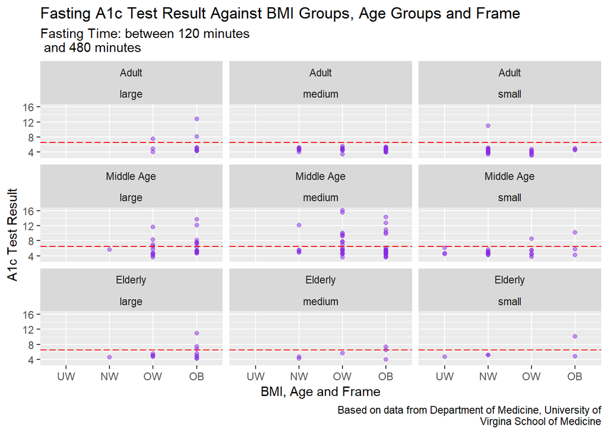

```r
#   Interaction of  x2 (age_grp) and x3 (frame)

ggplot(data=diabetes480) +
  geom_point(mapping = aes(x = bmi_grp, y = glyhb), na.rm = TRUE,
             color = "blueviolet", alpha = 0.5) +
  facet_wrap(age_grp ~ frame) +
  geom_hline(yintercept = 6.5, color = "red", linetype="longdash") +
  labs(x = "BMI, Age and Frame", y = "A1c Test Result",
       title = "Fasting A1c Test Result Against BMI Groups, Age Groups and Frame",
       subtitle = "Fasting Time: between 120 minutes\n and 480 minutes",
       caption = "Based on data from Department of Medicine, University of
       Virgina School of Medicine")
```